# Konsumprisindeksen - KPI

For å kunne sammenligne priser på en vare eller tjeneste benytter vi [konsumprisindeksen (KPI)](https://snl.no/konsumprisindeks). KPI er et mål på prisnivået til varer og tjenester som kjøpes av husholdninger og viser prisutviklingen for disse, sammenlignet med et basisår. Den prosentvise endringen i KPI brukes som et generelt mål på inflasjonen i en økonomi.

[figure not shown]

**Norsk kronestykke. Fotograf: Ilja Hendel**

### KPI - totalindeks

SSB har i sin API med [ferdige datasett](https://data.ssb.no/api/v0/dataset/) flere tabeller for konsumprisindeksen. Vi starter med å se på [Konsumprisindeks - totalindeks. 1979M01 - siste måned](https://data.ssb.no/api/v0/dataset/1086?lang=no). Bildet under viser informasjonen på SSBs nettside.

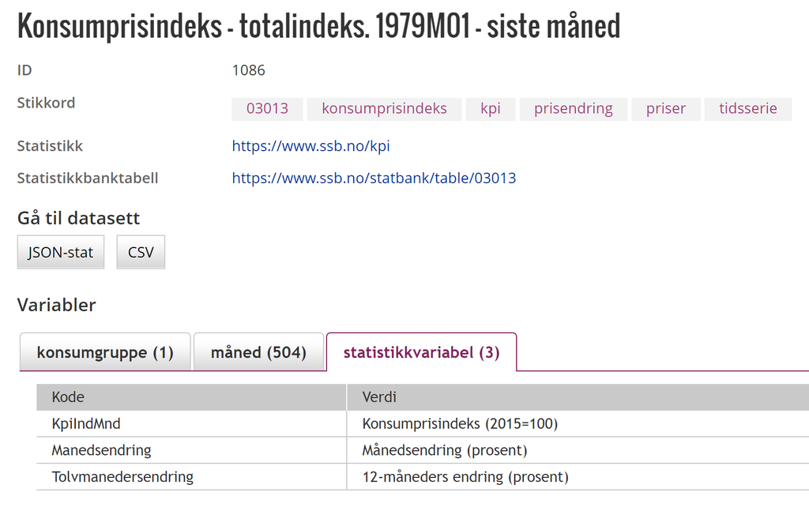

**Konsumprisindeksen - Totalindeks**

Vi ser at tabellen inneholder 3 variabler. Konsumprisindeksen med 2015 som basis (=100), prosentvis månedsendring og 12-måndeders prosentvis endring. Neste steg er å laste ned tabellen i RStudio.

### Data via kode

Vi kan starte med å laste ned `.csv` fila. Vi “peker” på CSV ikonet på nettsiden, høyreklikker, og kopierer url’en.

[figure not shown]

**Kopier CSV url til tabellen**

Deretter kan vi “lime” denne url’en inn i koden som leser csv fila. Vi benytter funksjonen `data.table::fread()` som leser store `*.csv` filer meget effektivt.

```r
library(data.table)
kpi_csv <- fread("http://data.ssb.no/api/v0/dataset/1086.csv?lang=no")
kpi_csv
```

```
           konsumgruppe m\xe5ned               statistikkvariabel
   1: TOTAL Totalindeks  1979M01      Konsumprisindeks (2015=100)
   2: TOTAL Totalindeks  1979M01       M\xe5nedsendring (prosent)
   3: TOTAL Totalindeks  1979M01 12-m\xe5neders endring (prosent)
   4: TOTAL Totalindeks  1979M02      Konsumprisindeks (2015=100)
   5: TOTAL Totalindeks  1979M02       M\xe5nedsendring (prosent)
  ---
1535: TOTAL Totalindeks  2021M08       M\xe5nedsendring (prosent)
1536: TOTAL Totalindeks  2021M08 12-m\xe5neders endring (prosent)
1537: TOTAL Totalindeks  2021M09      Konsumprisindeks (2015=100)
1538: TOTAL Totalindeks  2021M09       M\xe5nedsendring (prosent)
1539: TOTAL Totalindeks  2021M09 12-m\xe5neders endring (prosent)
      03013: Konsumprisindeks, etter konsumgruppe, m\xe5ned og statistikkvariabel
   1:                                                                        25,3
   2:                                                                           0
   3:                                                                         5,9
   4:                                                                        25,4
   5:                                                                         0,4
  ---
1535:                                                                           0
1536:                                                                         3,4
1537:                                                                       117,5
1538:                                                                           1
1539:                                                                         4,1
```

Det er noen utfordringer med norsk tegnsett i dette formatet. Formateringer har gjort at en norsk “å” er blitt til `\xe5`. Vi kan derfor forsøke å lese `JSON` fila. Samme prosedyre som sist, og vi finner url lenka til tabellen.

[figure not shown]

**Kopier JSON url til tabellen**

Denne gangen benytter vi oss av funksjonen `rjstat::fromJSONstat(url)` for å laste ned tabellen.

```r
library(rjstat)
url <- "http://data.ssb.no/api/v0/dataset/1086.json?lang=no"
kpi_json <- fromJSONstat(url)
str(kpi_json)
```

```
List of 1
 $ 03013: Konsumprisindeks, etter konsumgruppe, måned og statistikkvariabel:'data.frame':   1539 obs. of  4 variables:
  ..$ konsumgruppe      : chr [1:1539] "Totalindeks" "Totalindeks" "Totalindeks" "Totalindeks" ...
  ..$ måned             : chr [1:1539] "1979M01" "1979M01" "1979M01" "1979M02" ...
  ..$ statistikkvariabel: chr [1:1539] "Konsumprisindeks (2015=100)" "Månedsendring (prosent)" "12-måneders endring (prosent)" "Konsumprisindeks (2015=100)" ...
  ..$ value             : num [1:1539] 25.3 0 5.9 25.4 0.4 5.8 25.5 0.4 4.9 25.6 ...
```

Objektet `kpi_json` er en `liste` med 1 datasett i. Vi trekker ut informasjonen i denne første listen ved å benytte doble firkantparentes, der 1-tallet indikerer at vi vil ha det første elementet i listen.

```r
tabell <- kpi_json[[1]]
str(tabell)
```

```
'data.frame':   1539 obs. of  4 variables:
 $ konsumgruppe      : chr  "Totalindeks" "Totalindeks" "Totalindeks" "Totalindeks" ...
 $ måned             : chr  "1979M01" "1979M01" "1979M01" "1979M02" ...
 $ statistikkvariabel: chr  "Konsumprisindeks (2015=100)" "Månedsendring (prosent)" "12-måneders endring (prosent)" "Konsumprisindeks (2015=100)" ...
 $ value             : num  25.3 0 5.9 25.4 0.4 5.8 25.5 0.4 4.9 25.6 ...
```

```r
head(tabell)
```

```
  konsumgruppe   måned            statistikkvariabel value
1  Totalindeks 1979M01   Konsumprisindeks (2015=100)  25.3
2  Totalindeks 1979M01       Månedsendring (prosent)   0.0
3  Totalindeks 1979M01 12-måneders endring (prosent)   5.9
4  Totalindeks 1979M02   Konsumprisindeks (2015=100)  25.4
5  Totalindeks 1979M02       Månedsendring (prosent)   0.4
6  Totalindeks 1979M02 12-måneders endring (prosent)   5.8
```

Vi har nå et datasett som kalles `tabell` der formateringen av norsk tegnsett ser ok ut.

### Velge ut bestemte rader

Vi har følgende antall observasjoner `n` i de tre kategoriene for variabelen `statistikkvariabel`.

```r
suppressPackageStartupMessages(library(tidyverse))

tabell %>%
  group_by(statistikkvariabel) %>%
  summarise(n=n())
```

```
# A tibble: 3 x 2
  statistikkvariabel                n
  <chr>                         <int>
1 12-måneders endring (prosent)   513
2 Konsumprisindeks (2015=100)     513
3 Månedsendring (prosent)         513
```

Hver kategori har like mange observasjoner, men vi er kun interessert i konsumprisindeksen.

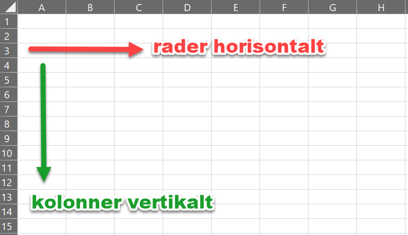

**Rader er horisontale observasjoner i en datatabell**

Vi ønsker nå å trekke ut, eller filtrere på de radene som inneholder konsumprisindeksen. Dette oppnår vi med kode ved å filtrerer på totalindeksen på `statistikkvariabel` der den er lik (`==`) `Konsumprisindeks (2015=100)`. Vi kaller det nye datasettet `kpi`.

```r
kpi <-
  tabell %>%
  filter(statistikkvariabel=="Konsumprisindeks (2015=100)") %>%
  as_tibble()

kpi
```

```
# A tibble: 513 x 4
   konsumgruppe måned   statistikkvariabel          value
   <chr>        <chr>   <chr>                       <dbl>
 1 Totalindeks  1979M01 Konsumprisindeks (2015=100)  25.3
 2 Totalindeks  1979M02 Konsumprisindeks (2015=100)  25.4
 3 Totalindeks  1979M03 Konsumprisindeks (2015=100)  25.5
 4 Totalindeks  1979M04 Konsumprisindeks (2015=100)  25.6
 5 Totalindeks  1979M05 Konsumprisindeks (2015=100)  25.7
 6 Totalindeks  1979M06 Konsumprisindeks (2015=100)  25.8
 7 Totalindeks  1979M07 Konsumprisindeks (2015=100)  26
 8 Totalindeks  1979M08 Konsumprisindeks (2015=100)  26
 9 Totalindeks  1979M09 Konsumprisindeks (2015=100)  26.1
10 Totalindeks  1979M10 Konsumprisindeks (2015=100)  26.3
# … with 503 more rows
```

Vår neste oppgave er å formatere `måned` som en dato, og ikke som tekst (`<chr>`). Vi benytter tegnet `M` som separator, da får vi år og måned for seg, og kan formatere `dato` variabelen med dagtall 1, altså den første i hver måned for alle observasjonene.

```r
library(lubridate)
kpi <-
  kpi %>%
  separate(måned, into=c("år", "måned"), sep="M") %>%
  mutate(dato=ymd(paste(år, måned, "1"))) %>%
  select(dato, konsumgruppe, statistikkvariabel, value)

kpi
```

```
# A tibble: 513 x 4
   dato       konsumgruppe statistikkvariabel          value
   <date>     <chr>        <chr>                       <dbl>
 1 1979-01-01 Totalindeks  Konsumprisindeks (2015=100)  25.3
 2 1979-02-01 Totalindeks  Konsumprisindeks (2015=100)  25.4
 3 1979-03-01 Totalindeks  Konsumprisindeks (2015=100)  25.5
 4 1979-04-01 Totalindeks  Konsumprisindeks (2015=100)  25.6
 5 1979-05-01 Totalindeks  Konsumprisindeks (2015=100)  25.7
 6 1979-06-01 Totalindeks  Konsumprisindeks (2015=100)  25.8
 7 1979-07-01 Totalindeks  Konsumprisindeks (2015=100)  26
 8 1979-08-01 Totalindeks  Konsumprisindeks (2015=100)  26
 9 1979-09-01 Totalindeks  Konsumprisindeks (2015=100)  26.1
10 1979-10-01 Totalindeks  Konsumprisindeks (2015=100)  26.3
# … with 503 more rows
```

Til sist i koden velger vi ut hvilke variabler som skal være med i `kpi` og rekkefølgen til kolonnene.

Vi lager et raskt plot av konsumprisindeksen i perioden.

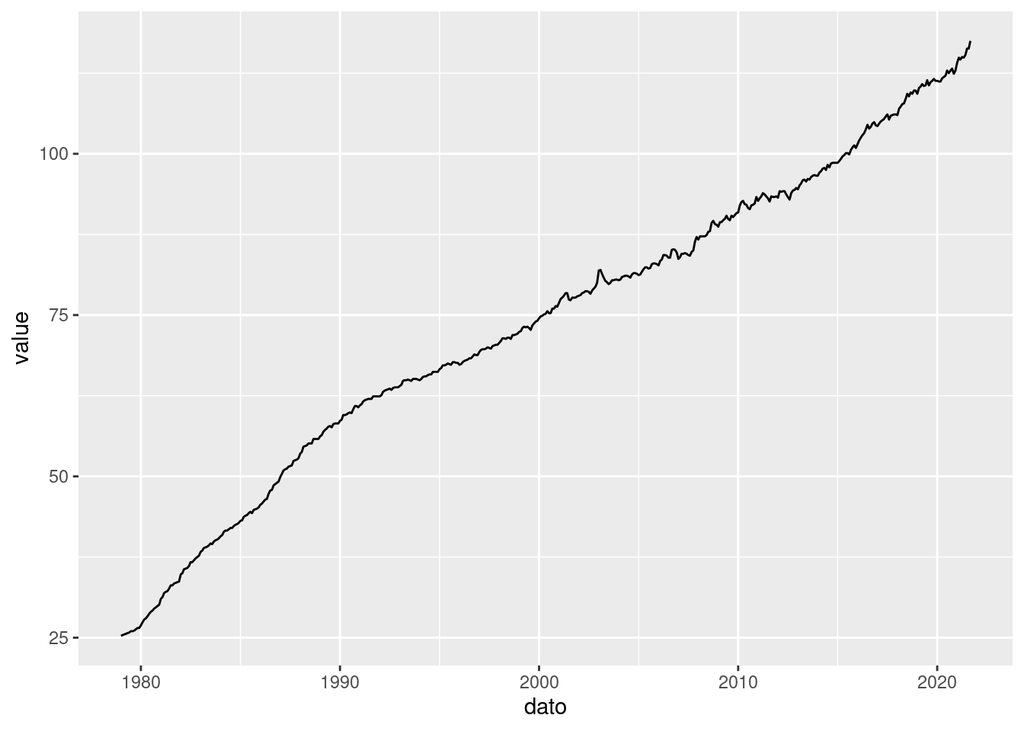

```r
kpi %>%
  ggplot(aes(x=dato, y=value)) +
  geom_line()
```

Denne figuren kan vi enkelt forbedre litt.

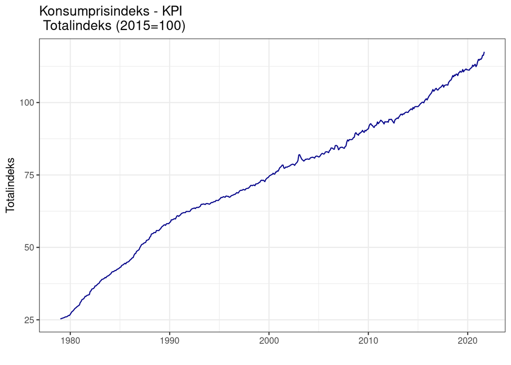

```r
kpi %>%
  ggplot(aes(x=dato, y=value)) +
  geom_line(col="dark blue") +
  labs(title="Konsumprisindeks - KPI \n Totalindeks (2015=100)",
       x =" ",
       y = "Totalindeks") +
  theme_bw()
```

### Basis i en indeks?

Konsumprisindeksen har som basis, 2015=100. Hva innebærer dette? La oss se på de faktiske KPI tallene for 2015.

```r
kpi %>%
  filter(dato >= "2015-01-01" & dato <= "2015-12-01")
```

```
# A tibble: 12 x 4
   dato       konsumgruppe statistikkvariabel          value
   <date>     <chr>        <chr>                       <dbl>
 1 2015-01-01 Totalindeks  Konsumprisindeks (2015=100)  98.6
 2 2015-02-01 Totalindeks  Konsumprisindeks (2015=100)  98.9
 3 2015-03-01 Totalindeks  Konsumprisindeks (2015=100)  99.2
 4 2015-04-01 Totalindeks  Konsumprisindeks (2015=100)  99.6
 5 2015-05-01 Totalindeks  Konsumprisindeks (2015=100)  99.8
 6 2015-06-01 Totalindeks  Konsumprisindeks (2015=100) 100.
 7 2015-07-01 Totalindeks  Konsumprisindeks (2015=100) 100.
 8 2015-08-01 Totalindeks  Konsumprisindeks (2015=100)  99.9
 9 2015-09-01 Totalindeks  Konsumprisindeks (2015=100) 101.
10 2015-10-01 Totalindeks  Konsumprisindeks (2015=100) 101
11 2015-11-01 Totalindeks  Konsumprisindeks (2015=100) 101.
12 2015-12-01 Totalindeks  Konsumprisindeks (2015=100) 101.
```

Dersom vi beregner gjennomsnittet av KPI verdiene for 2015 vil de være lik 100. For enkelhetens skyld lager vi først en variabel på år (`year`) som vi deretter filtrerer på.

```r
kpi %>%
  mutate(year=year(dato)) %>%
  filter(year==2015) %>%
  summarise(mean(value))
```

```
# A tibble: 1 x 1
  `mean(value)`
          <dbl>
1           100
```

Endrer indeksen seg fra 100 til 102.5, er dette en økning på 2.5 poeng (102.5-100=2.5). Den prosentvise endringen i indeksen er:

$$\frac{2.5}{100}=0.025=2.5\%$$

Denne prosentvise endringen blir enkel fordi basis er 100 i utregningen. Endrer indeksen seg fra 89 til 91.5 er økningen fremdeles på 2.5 poeng, men den prosentvise endringen er:

$$\frac{2.5}{89}=0.028=2.8\%$$

Endringen er nå 2.8% fordi basis, altså indekstallet vi beregner endringen fra er 89. Alle positive indeksendringer fra basis kan dermed tolkes som prosentvise endringer. Hva om vi ønsker å endre basis fra 2015 til et annet år? Hvordan gjør vi det? La oss endre basis til 2010.

```r
kpi %>%
  mutate(year=year(dato)) %>%
  filter(year==2010) %>%
  summarise(mean(value))
```

```
# A tibble: 1 x 1
  `mean(value)`
          <dbl>
1          92.1
```

Vi ser at gjennomsnittet av KPI i 2010 er 92.09. Dette tallet er nå vår nye basis, og vi kan re-indeksere KPI med å dele alle KPI observasjoner med dette tallet. Dette gjør vi i to steg. Først beregner vi gjennomsnittet til den nye basisen i 2010, og lagrer det i objektet `b2010`, med variabelnavn `ny_basis_2010` deretter beregner vi den nye rebaserte indeksen.

```r
b2010 <-
  kpi %>%
  mutate(year=year(dato)) %>%
  filter(year==2010) %>%
  summarise(ny_basis_2010=mean(value))

kpi <-
  kpi %>%
  mutate(KPI_2010=100*value/b2010$ny_basis_2010)
```

Vi kan nå lage en ny figur med begge indeksene i. Først gir vi den gamle indeksen et nytt navn (`KPI_2015`), deretter velger vi kun dato og de to indeksene, og gjør datasettet om til et “langt” format. Forsøk å kjøre koden frem til plottet og se hvordan datatabellen er strukturert før figuren lages.

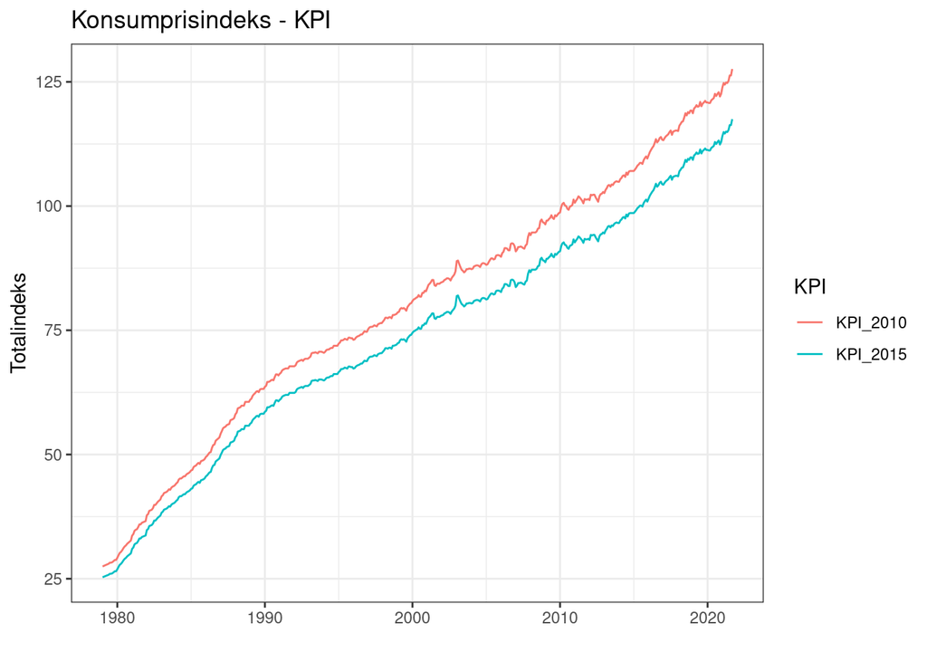

```r
kpi %>%
  rename(KPI_2015=value) %>%
  select(dato, KPI_2010, KPI_2015) %>%
  pivot_longer(-dato,
               names_to = "KPI",
               values_to = "indeks") %>%
  ggplot(aes(x=dato, y=indeks, col=KPI)) +
           geom_line() +
  labs(title="Konsumprisindeks - KPI",
       x =" ",
       y = "Totalindeks") +
  theme_bw()
```

Vi ser at konsumprisindeksen ser helt lik ut. Det er bare skalaen, der den er lik 100 som endrer seg.

### Oppgave 1

Rebaser konsumprisindeksen med November 2019 lik 100, og lag en figur. Unngå å bruke kode der du skriver verdien for KPI i november 2019 inn som et tall.

### VGs matbørs

[VGs matbørs](https://www.vg.no/spesial/matborsen/) er en viktig uavhengig prissammenligning for dagligvarer. VG samler inn prisdata for en representativ handlekurv hos de ulike dagligvarekjedene. I oktober 2018 kostet i gjennomsnitt en handlekurv 3483 kroner (TOTALSUM), basert på prisinformasjon fra 6 kjeder. I september 2020 kostet en gjennomsnittlig handlekurv 3696 kroner (TOTALSUM), også med data fra 6 kjeder. Denne informasjonen innebærer en økning i pris på 6.11 prosent.

I oktober 2018 er konsumprisindeksen 109.3, mens den i september 2020 er 112.9. Dette tilsvarer en prisøkning på 3.6 poeng i perioden (112.9 - 109.3), eller 3.29 prosent.

Vi ser dermed at prisen på matvarene i VGs undersøkelse har økt med ytterligere 2.81 prosent.

### Oppgave 2

Gå til de respektive sidene for VGs matbørs. Finn tallene for matbørsen i oktober 2018 og september 2020, og repliser beregningene over ved bruk av kode.

### Oppgave 3

SSB har i sin API med ferdige datasett, [Konsumprisindeks - undergruppenivå2. 1979M01 - siste måned](https://data.ssb.no/api/v0/dataset/1094?lang=no). I denne oppgaven laster du ned denne datatabellen. Deretter velger du en kategori fra SSB’s tabell som samsvarer med en kategori i VGs matbørs (brød og bakevarer, drikkevarer osv.). Så sammenligner du den prosentvise prisendringen i denne kategorien fra oktober 2018 til september 2020 med den prosentvise endringen i konsumprisindeksen i samme periode.

## Prosentvise endringer i en indeks

Vi skal også benytte formelen:

$$\% \triangle x_t \cong 100 \times \left [ \ln(x_t)-\ln(x_{t-1}) \right ]$$

SSB har allerede gjort denne beregningen, men vi vil gjerne gjøre vår egen. For syns skyld vil vi også sammenligne de to beregningene. Vi merker oss at første observasjon av tidsserien ikke er definert.

```r
tabell2 <-
  tabell %>%
  filter(statistikkvariabel != "12-måneders endring (prosent)") %>%
  separate(måned, into = c("år", "måned"), sep="M") %>%
  mutate(dato = ymd(paste(år, måned, "1"))) %>%
  select(dato, statistikkvariabel, value) %>%
  pivot_wider(names_from = "statistikkvariabel") %>%
  rename(KPI = "Konsumprisindeks (2015=100)",
         SSB_dp ="Månedsendring (prosent)") %>%
  mutate(dp  = 100*(KPI - lag(KPI))/lag(KPI),
         lndp.v1 = 100*(log(KPI) - log(lag(KPI))),
         lndp.v2 = c(NA, 100*diff(log(KPI))))

head(tabell2)
```

```
# A tibble: 6 x 6
  dato         KPI SSB_dp     dp lndp.v1 lndp.v2
  <date>     <dbl>  <dbl>  <dbl>   <dbl>   <dbl>
1 1979-01-01  25.3    0   NA      NA      NA
2 1979-02-01  25.4    0.4  0.395   0.394   0.394
3 1979-03-01  25.5    0.4  0.394   0.393   0.393
4 1979-04-01  25.6    0.4  0.392   0.391   0.391
5 1979-05-01  25.7    0.4  0.391   0.390   0.390
6 1979-06-01  25.8    0.4  0.389   0.388   0.388
```

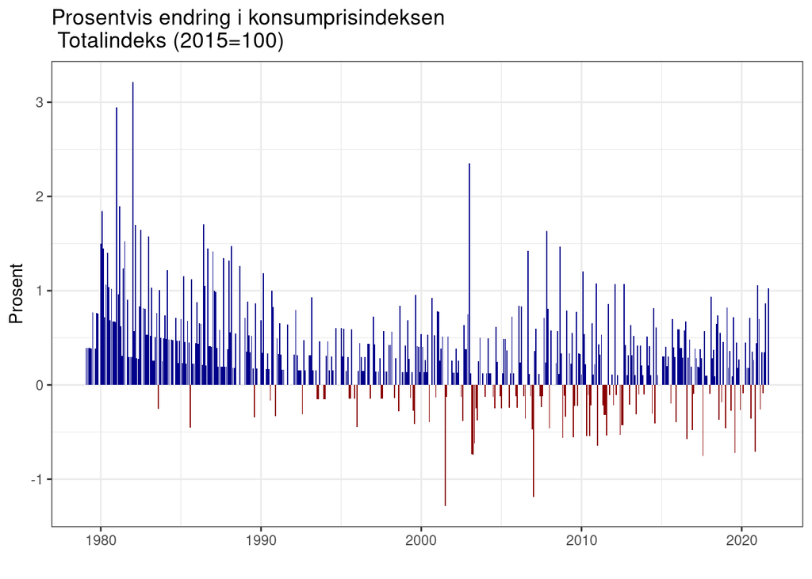

```r
tabell2 %>%
  filter(dato >= "1979-02-01") %>%
  mutate(positiv=lndp.v2 >= 0) %>%
  ggplot(aes(x=dato, y=lndp.v2, fill=positiv)) +
  geom_col(position = "identity") +
  scale_fill_manual(values = c("dark red", "dark blue"), guide = FALSE) +
  labs(title="Prosentvis endring i konsumprisindeksen \n Totalindeks (2015=100)",
       x = " ",
       y = "Prosent") +
  theme_bw()
```

Det er mange flere positive endringer i konsumprisindeksen sammenlignet med måneder med nedgang.

### Oppgave 4

Finn ut hvor mange måneder det er positive endringer, der $\triangle KPI_t>=0$, sammenlignet med negative endringer. Beregn også dette forholdet i prosent.

Den kumulative prosentvise endringen viser hvor mye prisene har økt siden januar 1979.

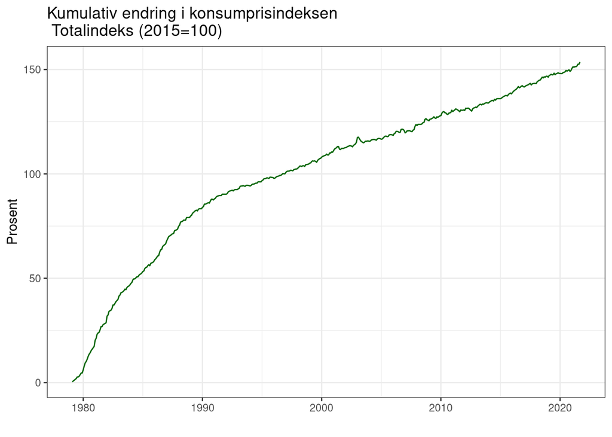

```r
tabell2 %>%
  filter(dato >= "1979-02-01") %>%
  select(dato, lndp.v2) %>%
  mutate(kumulativKPI=cumsum(lndp.v2)) %>%
  ggplot(aes(x=dato, y=kumulativKPI)) +
  geom_line(col="dark green") +
  labs(title="Kumulativ endring i konsumprisindeksen \n Totalindeks (2015=100)",
       x = " ",
       y = "Prosent") +
  theme_bw()
```

### Oppgave 5

Finn ut hvor mange måneder det gikk før den kumulative endringen i konsumprisindeksen var henholdsvis 50, 100 og 150 prosent.

## `R` kode fra dette caset

```r
getwd()
setwd("~/undervisning/SOK1004")
knitr::purl("case_5_kpi.Rmd")
```